# Quantitative Genetics – PCB6555

Dominance and Biometric Model

Felipe Ferrão and Marcio Resende Jr

University of Florida – October, 2020

**What we know, so far:**

- Parents pass on alleles – not genotypes – to their offsprings
- Allele effects is a function of genotypic values and allele frequencies
- Breeding value of an individual is twice the mean value of the progeny that would be produced by a single genotype under random mating expressed as a difference from the population mean.

**Plan for today:**

- Dominance deviation
- The Regression biometric model
- Hands-on: Regression and Least Square

# Theory

## Introduction

The next step in understanding the Mendelian basis of quantitative trait variation is to move back to the level of the genotype. In terms of population mean values, we can divide the genotypic mean value into its components due to additive effects of alleles and the dominance effects of genotypes (G=A+D). Due to dominance, genotypes may not completely reflect the combinations of the alleles that make them up. Therefore, when there is no dominance, the average value of progeny is a perfect representation of the parental genotypic value.

## Dominance as deviations

Expressions for the dominance deviations are originally obtained by taking the difference between the genotypic value and the breeding value for each genotype. For the A1 A1 genotype, the difference between the genotypic value and the population mean in equation is:

$$\begin{align*}
M_G = a -[a(p-1)+ 2pqd]\\
M_G= 2q(a-dp)\\
D_{A1A1}= M_g - BV_{A1A1} \\
= 2q(a-dp) - BV \\
= 2q(a-dp) - 2q\alpha \\
= 2q(a-dp) - 2q(a+d(q-p)) \\
= 2qa -2qdp - 2qa -2q^2d + 2qdp \\
= -2q^2d
\end{align*}$$

In summary:

[output not shown]

## Regression Biometric Model

### Simple Regression

Depending on the causal connections between two variables, *x* and *y*, their true relationship may be linear and it always serve as a first approximation. In this case, we can represent it as:

$$y = \alpha + \beta x + e$$
where $\alpha$ is the y-intercept, $\beta$ is the slope of the line (also known as the regression coefficient), and *e* is the residual error. When information on *x* is used to predict *y*, *x* is referred to as the predictor or independent variable and *y* as the response or dependent variable.

The objective of linear regression analysis is to estimate the model parameters, $\alpha$ and $\beta$, that give the “best fit” for the joint distribution of $x$ and $y$. With those estimated values, we can perform predictions and inference. By inference, we refer to the steps necessary of estimating the regression model and assesing uncertainty in the fit.

Below there is a graphical explanation of least-squares linear regression with some important considerations:

- Straight lines can be drawn in multiple ways using different combinations of slope and intercept.
- What is the best fit?
- One way to solve this is to find the combination of slope and intercept that create a line and minimizes the error between the original and predicted values. Formally, finds the parameters values that minimizes the residual sum of squares.

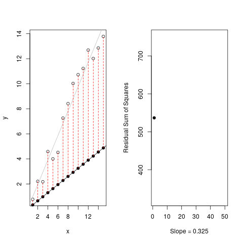

Least-squares linear regression

Mathematically, the least-square soluction for both $\alpha$ and $\beta$ can be computed as:

$$\alpha = \bar{y} - \hat{\beta}\bar{x}$$
$$\hat{\beta} = \dfrac{\sum (x_i-\bar{x})y_i}{\sum (x_i - \bar{x})^2} = \dfrac{Cov(x,y)}{Var(x)}$$

Thus, the least-squares estimators for the intercept and slope of a linear regression are simple functions of the observed means, variances, and covariances. From the standpoint of quantitative genetics, this property is exceedingly useful, since such statistics are readily obtainable from phenotypic data.

### Biometric Model

The connection between the genotypic values and the genotype frequencies on one hand and the breeding values and dominance deviations on the other can be easier illustrated using least-squares regression. In the case of Biometric Model we will use the same logic, but the genotypic value will be modelled as a function of the genotype (or the number of a given allele) as presented in the Figure 1.

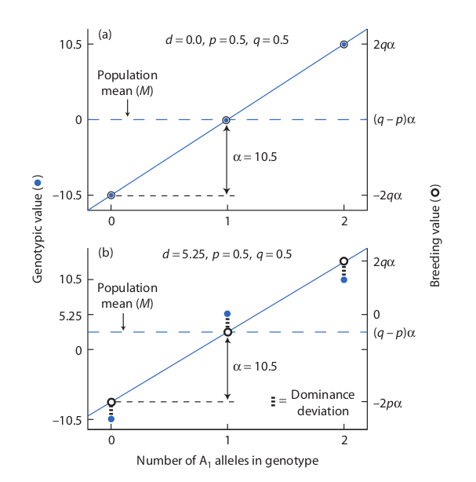

Fig1 - Regression Biometric Model from Hamilton, 2009

$$\begin{align*}
b = \dfrac{Cov(x,y)}{V(x)}\\
Cov(x,y) = \sum f_i X_i Y_i - \sum f_iX_i \sum f_i Y_i\\
= 2pq[a+d(q-p)]\\
V(x) = \sum f_i X^2_i - (\mu_x)^2\\
= 2pq \\
b = \dfrac{Cov(x,y)}{V(x)} = a + d(q-p) = \alpha
\end{align*}$$

**Important:**

- The average effec of an allele substitution ($\alpha$) is equal to slope of regression line. It represents the average change in genotypic value per unit change in the number of alleles at the population level.
- The original definition of the average effect of gene substitution was presented by Fisher (1918, 1941) in terms of linear regression.
- Graphically, dominance can be interpreted as deviationd from the breeding values.
- In the absence of dominance, breeding values and genotypic values coincide.

# Hands-on

## Simulation

- Tow example showing how to fit simple regression models in R.
- Results using the `lm` function and formulas are the same.

```r
# Simulation
x=1:20
n = length(x)
a = 0.2
b = 0.3
sigma=0.5
y = a + b*x + sigma*rnorm(n)

# Fitting the model
b = cov(x,y)/var(x)
a = mean(y) - b*mean(x)

# Using the lm function
summary(lm(y~x))
```

[output not shown]

# References

- Hamilton, 2009. Population Genetics, 1st edition. [Book link](https://www.amazon.com/Population-Genetics-Matthew-Hamilton/dp/1405132779)
- Falconer and Mackay, 1996. Introduction to Quantitative Genetics. [Book link](https://www.amazon.com/Introduction-Quantitative-Genetics-Douglas-Falconer/dp/0582243025)
- Gelman et al., 2020. Regression and Other Stories. [Book link](https://www.amazon.com/Regression-Stories-Analytical-Methods-Research/dp/110702398X)